# Uncertainty in joint ancestral state reconstruction

James D. Boyko

## What this vignette is for

A marginal reconstruction asks, node by node, *what state was this ancestor in?* A joint reconstruction asks a different question: *what sequence of states across the whole tree best explains the data?* If your biology is about trajectories — when a trait arose, how many times it was lost, whether two clades acquired it independently — the joint reconstruction is the estimate you want, because stringing together the best marginal state at each node can produce a history that is improbable as a path.

The problem is that classical joint algorithms return one history and no uncertainty. This vignette walks through the fix described in Boyko et al. (2025): sample the joint posterior, cluster the samples into a handful of distinct narratives (“reconstruction axes”), and read off where on the tree those narratives actually disagree.

Everything here runs in under a minute on the example data. You will need `Rtsne`, `dbscan` and `proxy` alongside `corHMM`.

```r
library(corHMM)
library(ape)

state_cols <- c("#F2F2F2", "#7EA6E0", "#B85450")  # one colour per character state
```

## 1. Fit a model and get the best joint reconstruction

We use the `primates` data shipped with corHMM: two binary traits, which `corHMM` collapses to the three observed combinations `0|0`, `0|1` and `1|1`.

```r
data(primates)
phy <- ladderize(multi2di(primates[[1]]))
cor_dat <- primates[[2]]

focal <- corHMM(phy, cor_dat,
                rate.cat = 1,
                model = "ER",
                node.states = "joint",
                root.p = "maddfitz")
phy <- ladderize(focal$phy)   # the tree corHMM actually used
```

`focal$states` holds the single best joint history. Plotting it gives the estimate most papers stop at.

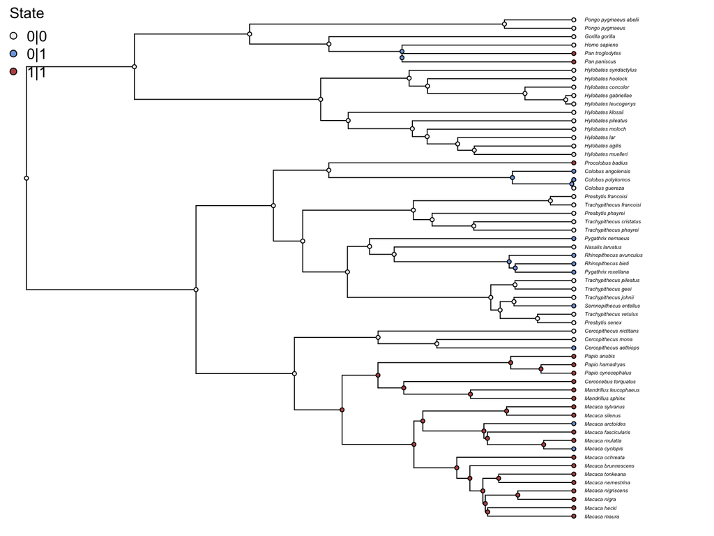

```r
plot(phy, cex = 0.35, label.offset = 1, no.margin = TRUE)
tiplabels(pch = 21, bg = state_cols[focal$tip.states], cex = 0.6)
nodelabels(pch = 21, bg = state_cols[focal$states], cex = 0.6)
legend("topleft", legend = c("0|0", "0|1", "1|1"), pch = 21,
       pt.bg = state_cols, bty = "n", title = "State")
```

## 2. Sample the joint posterior

`compute_joint_ci()` samples complete histories in proportion to their joint posterior probability, using the two-pass conditional sampling of stochastic character mapping. It keeps sampling in batches until `max_samples` is reached, discards duplicates, and drops likelihood outliers.

```r
set.seed(0104)
joint_ci <- compute_joint_ci(focal, batch_size = 100, max_samples = 1000)

state_df <- joint_ci$state_df   # rows = reconstructions, columns = internal nodes
n_recon <- nrow(state_df)
n_recon
```

```
## [1] 758
```

That is 758 distinct histories that are all consistent with the same fitted model. Their likelihoods span a narrow band, which is the point: many of them are nearly as good as the best.

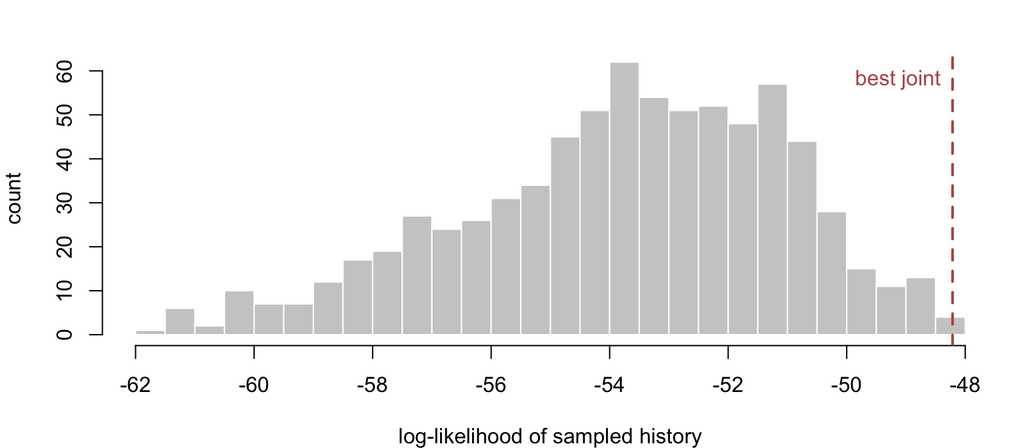

```r
par(mar = c(4, 4, 2, 1))
hist(joint_ci$lnliks, breaks = 40, col = "grey80", border = "white",
     main = "", xlab = "log-likelihood of sampled history", ylab = "count")
abline(v = joint_ci$best_lnlik, lty = 2, lwd = 2, col = "#B85450")
text(joint_ci$best_lnlik, par("usr")[4] * 0.9, "best joint  ", adj = 1, col = "#B85450")
```

Before any clustering, it is worth looking at the raw sample. `plot_raw_recon()` draws one row per reconstruction and one column per internal node.

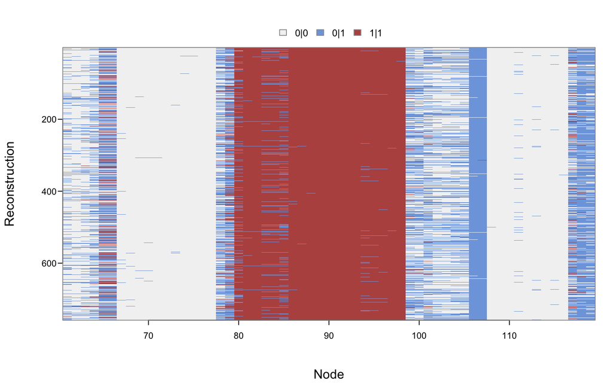

```r
plot_raw_recon(as.matrix(state_df),
               state_colors = state_cols,
               state_labels = c("0|0", "0|1", "1|1"))
```

Most nodes are the same colour in every row — those are settled. A handful of columns are mottled, and those are where the histories genuinely diverge. There is visible vertical structure, but rows arrive in sampling order, so we need to sort them.

## 3. A distance between reconstructions

Two histories that differ at five scattered nodes are not really telling different stories; two that differ at five adjacent nodes are. `phylo_aware_dist_local()` encodes exactly that: it sums `exp(1 / d)` over all pairs of disagreeing nodes, where `d` is the node distance on a cladogram, so clustered disagreements are penalised much more heavily than isolated ones.

Register it with `proxy` and build the full distance matrix.

```r
cladogram <- phy
cladogram$edge.length <- rep(1, nrow(cladogram$edge))
phylo_dist <- ape::dist.nodes(cladogram)[-(1:Ntip(phy)), -(1:Ntip(phy))]

try(proxy::pr_DB$set_entry(FUN = phylo_aware_dist_local, names = "PhyloSpreadDistLocal"),
    silent = TRUE)

D <- proxy::dist(as.matrix(state_df),
                 method = "PhyloSpreadDistLocal",
                 phylo_dist = phylo_dist)
```

## 4. Consensus clustering

A single t-SNE plus DBSCAN run is quick but seed-dependent, and it is easy to over-read a clustering that would not survive a different seed. The published approach repeats the embedding over many seeds, records how often each pair of reconstructions lands in the same cluster, and clusters *that* co-association matrix.

Two parameters to set. `minPts` is the smallest group you are willing to call a cluster; here we use 5% of the sample, though for the several-thousand-reconstruction datasets in the paper 0.5% is more appropriate. `eps` is the neighbourhood radius, read off the knee of a k-nearest-neighbour distance plot.

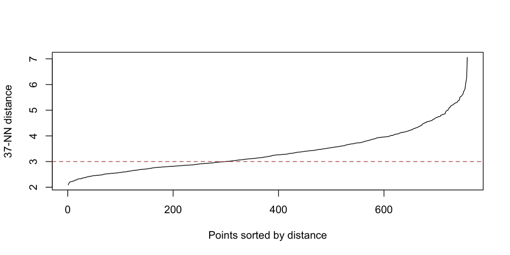

```r
min_pts <- round(0.05 * n_recon)
eps <- 3

set.seed(1)
Y1 <- Rtsne::Rtsne(D)$Y
dbscan::kNNdistplot(Y1, k = min_pts - 1, minPts = min_pts)
abline(h = eps, lty = 2, col = "#B85450")
```

Where the curve has a sharp bend, take `eps` there. This one rises smoothly, which is itself informative: the reconstructions do not fall into cleanly separated dense islands. We take a value on the lower shoulder, because anything above about 4 swallows the whole sample into a single cluster.

```r
table(dbscan::dbscan(Y1, eps = eps, minPts = min_pts)$cluster)   # 0 = noise
```

```
##
##   0   1   2   3   4
## 142 192 151 196  77
```

This is exactly the fragility the consensus step exists to absorb. Repeat across seeds and let agreement, rather than one lucky embedding, decide the grouping. Twenty-five seeds is enough here; the paper used 1,000.

```r
n_seeds <- 25
co <- matrix(0, n_recon, n_recon)

for (s in seq_len(n_seeds)) {
  set.seed(s)
  Y <- Rtsne::Rtsne(D)$Y
  g <- dbscan::dbscan(Y, eps = eps, minPts = min_pts)$cluster
  co <- co + (outer(g, g, "==") & outer(g != 0, g != 0, "&"))
}
co <- co / n_seeds   # probability that a pair clusters together

hc <- hclust(as.dist(1 - co), method = "ward.D2")
```

Choosing the number of clusters is a judgement call, made by looking at where the dendrogram has room to cut and whether the co-association matrix shows clean blocks.

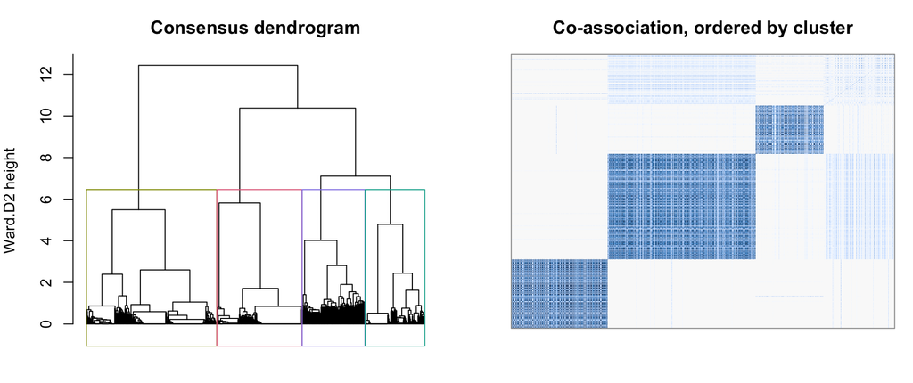

```r
k <- 4
clusters <- cutree(hc, k = k)
clust_cols <- hcl.colors(k, "Dark 3")

par(mfrow = c(1, 2), mar = c(2, 4, 3, 1))
plot(hc, labels = FALSE, hang = -1, main = "Consensus dendrogram",
     xlab = "", sub = "", ylab = "Ward.D2 height")
# rect.hclust draws left to right, which is not cluster order
rect.hclust(hc, k = k, border = clust_cols[unique(clusters[hc$order])])

ord <- order(clusters)
par(mar = c(3, 3, 3, 1))
image(co[ord, ord], col = hcl.colors(64, "Blues 3", rev = TRUE), axes = FALSE,
      main = "Co-association, ordered by cluster")
box(col = "grey60")
```

## 5. What the axes look like

Re-draw the raw sample, now sorted by cluster.

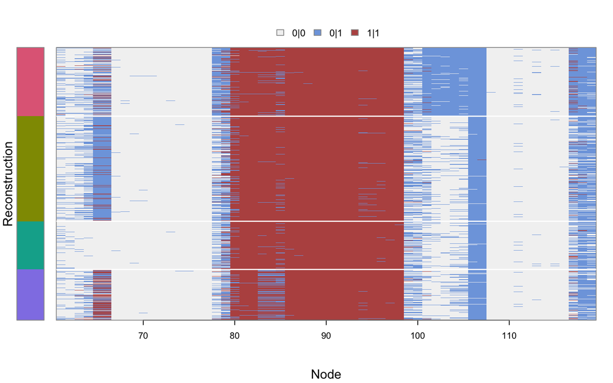

```r
plot_raw_recon(as.matrix(state_df), clusters, clust_cols,
               state_colors = state_cols,
               state_labels = c("0|0", "0|1", "1|1"))
```

The mottled columns from before have resolved into blocks: each axis commits to a particular state over a particular stretch of the tree. Section 6 pins down which nodes carry those commitments.

Crucially, these are not ranked alternatives. Their likelihood distributions overlap almost completely, so the data cannot distinguish between them.

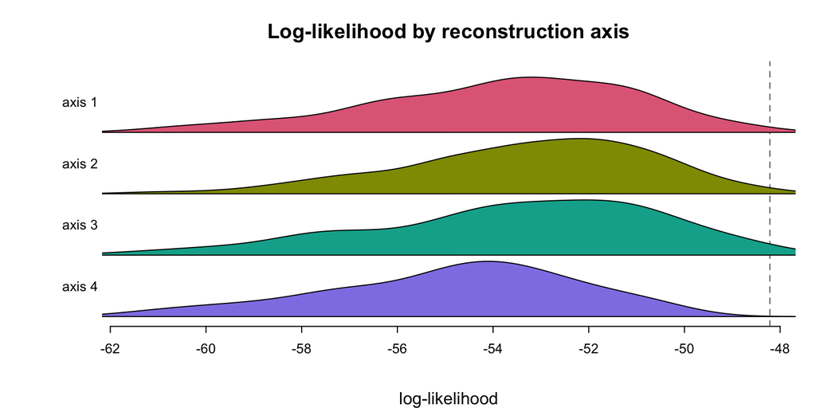

```r
par(mar = c(4, 5, 3, 1))
plot_stacked_densities(joint_ci$lnliks, clusters, cols = clust_cols,
                       cluster_labels = paste("axis", seq_len(k)),
                       best_lnlik = joint_ci$best_lnlik,
                       main = "Log-likelihood by reconstruction axis")
```

## 6. Where on the tree do they disagree?

`node_importance_by_cluster()` scores every node for every cluster. A node scores high when the cluster is internally consistent about it *and* differs from everything outside the cluster, so high scorers are the nodes that define an axis.

```r
node_imp <- node_importance_by_cluster(state_df, clusters)

top_n <- 2
important_nodes <- lapply(seq_len(k), function(i) {
  cl_nodes <- node_imp[node_imp$cluster == i, ]
  cl_nodes[order(-cl_nodes$importance)[seq_len(top_n)], ]
})

do.call(rbind, important_nodes)[, c("cluster", "node", "modal_state", "importance")]
```

|  | cluster | node | modal_state | importance |
| --- | --- | --- | --- | --- |
| 44 | 1 | 44 | 2 | 0.8429553 |
| 43 | 1 | 43 | 2 | 0.8425952 |
| 64 | 2 | 5 | 2 | 0.5383430 |
| 65 | 2 | 6 | 2 | 0.5383430 |
| 123 | 3 | 5 | 1 | 0.8894231 |
| 124 | 3 | 6 | 1 | 0.8894231 |
| 218 | 4 | 41 | 1 | 0.3627418 |
| 219 | 4 | 42 | 1 | 0.3158086 |

Taking the top 2 nodes per cluster keeps the figure legible and always returns something. A fixed threshold (`importance > 0.5`, as in the paper) is the alternative, but it can leave a diffuse cluster with no nodes at all, which will break the plot below. Read the scores as well as the ranks: an axis whose best node scores near 0.2 is not pinned to any particular ancestor, and should be described as diffuse rather than as a specific competing history.

Note that `important_nodes[[i]]` must be cluster `i`’s nodes — build the list by looping over `seq_len(k)`, not over `unique(clusters)`, which returns clusters in order of first appearance.

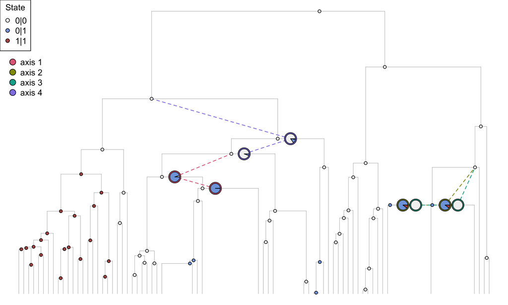

```r
par(mar = c(1, 1, 1, 1))
plot_clustered_phylo(
  phy = phy,
  state_df = state_df,
  cluster_assignments = clusters,
  node_states = focal$states,
  important_nodes = important_nodes,
  cluster_colors = clust_cols,
  state_colors = state_cols,
  state_labels = c("0|0", "0|1", "1|1"),
  legend_title = "State",
  phylogram_params = list(edge.color = "grey60"),
  point_params = list(cex = 0.8),
  segment_params = list(lty = 2, lwd = 1.4),
  outer_cex = 3.2, inner_rad = 1.0, node_offset = 2.6
)
legend("topleft", inset = c(0.01, 0.17), legend = paste("axis", seq_len(k)),
       pch = 21, pt.bg = clust_cols, pt.cex = 1.6, bty = "n")
```

Small points are the best joint reconstruction. Each large ringed pie is a diagnostic node for one axis, coloured by that axis and offset from its position on the tree so overlapping claims stay readable; the pie shows the states that axis assigns there. Because clustering has already separated the sample into distinct narratives, these pies show variation *within* an axis, not an average over everything — which is exactly what a marginal reconstruction would give you instead.

## 7. Turning axes into numbers

Reconstruction axes are only useful if they change downstream quantities. Counting transitions along edges is the simplest check.

```r
tips <- focal$tip.states   # already in tree order

count_events <- function(node_states) {
  st <- c(tips, node_states)
  anc <- st[phy$edge[, 1]]
  dec <- st[phy$edge[, 2]]
  c(gains = sum(dec > anc), losses = sum(dec < anc))
}

events <- t(apply(as.matrix(state_df), 1, count_events))

fmt <- function(x) sprintf("%.0f (%.0f-%.0f)", median(x), min(x), max(x))
do.call(rbind, lapply(seq_len(k), function(i) {
  z <- events[clusters == i, , drop = FALSE]
  data.frame(axis = i,
             n = sum(clusters == i),
             gains = fmt(z[, "gains"]),
             losses = fmt(z[, "losses"]),
             median_lnlik = round(median(joint_ci$lnliks[clusters == i]), 2))
}))
```

| axis | n | gains | losses | median_lnlik |
| --- | --- | --- | --- | --- |
| 1 | 191 | 7 (4-12) | 10 (7-16) | -53.58 |
| 2 | 292 | 10 (6-16) | 7 (3-12) | -52.99 |
| 3 | 134 | 10 (7-15) | 6 (2-10) | -53.14 |
| 4 | 141 | 10 (6-16) | 6 (2-14) | -54.46 |

The axes imply genuinely different histories: some favour more gains than losses, others the reverse, at essentially the same likelihood. A single point estimate would have reported one of these and hidden the rest. Each axis is a concrete, path-consistent hypothesis you can carry into whatever comes next.

## Adapting this to your data

- **Sampling effort.** Raise `max_samples` until the number of unique reconstructions plateaus. With a large tree or many states, expect thousands.
- **`minPts`.** Roughly the smallest cluster you would take seriously. 5% works for a few hundred reconstructions; drop toward 0.5% for several thousand.
- **`eps`.** Always read it off `kNNdistplot()` for your own data. Too small and everything is noise; too large and everything is one cluster.
- **Seeds.** More is better and the cost is linear. Twenty-five is a floor, not a target.
- **`k`.** Driven by the dendrogram and the co-association blocks, not by an information criterion. No block structure means no distinct axes.
- **Plotting.** On large trees raise `node_offset` and lower `outer_cex` and `inner_rad`, or restrict `important_nodes` to a single clade.

## Function reference

| Function | Purpose |
| --- | --- |
| `compute_joint_ci()` | Sample joint histories from their posterior |
| `phylo_aware_dist_local()` | Phylogenetically weighted distance between two histories |
| `plot_raw_recon()` | Raster of the sample, optionally sorted by cluster |
| `node_importance_by_cluster()` | Score nodes by how well they diagnose a cluster |
| `plot_stacked_densities()` | Likelihood distributions per cluster |
| `plot_clustered_phylo()` | Competing histories drawn on the tree |

## Reference

Boyko, J.D., Gontjes, K.J., Snitkin, E.S., and Smith, S.A. (2025). Resolving competing evolutionary histories in joint ancestral state reconstruction.